## Estatística Experimental em Ensaios Agropecuários

## Aula 1

- Análise de variância
- Estudo de Delineamentos experimentais
- Análise de variância Delineamento Inteiramente Causalizado
- Análise de variância para Blocos Qualitativo

–

Pacotes para Estatística Experiemental e entrada de dados

```r
library(ExpDes.pt)
library(gdata)
library(agricolae)
```

| Entrada de dados |
| --- |
| Como arquivo de texto |
| `r dados<-read.table("dados_teste.csv", header=TRUE,sep=",")` |
| Como planilha: vantagem de usar caracteres especiais sem dificultar a codificação,caso haja, usar este chunk inteiro com Ctrl+shift+enter |
| `r dados <- read.xls("dados_teste.xls",header = TRUE, dec = ",") #dados$Local<-iconv(dados$Local, "latin1", "UTF-8")` |
| Anexando os dados para que possamos chamar as variáveis pela label de cada variável |
| `r attach(dados)` |
| Condionaremos os dado num dataframe para que posso comportar tanto valores numéricos, inteiros e strings. |
| `r dados=data.frame(dados)` |
| Entendendo os dados como vetores e coordenadas |
| `r dados$Supress.10` |
| `## [1] 10 0 10 10 0 100 20 80 20 80 0 10 10 10 0` |
| `r Supress.10` |
| `## [1] 10 0 10 10 0 100 20 80 20 80 0 10 10 10 0` |
| `r dados[3,3]` |
| `## [1] 10` |
| `r dados$Supress.10[3]` |
| `## [1] 10` |
| `r dados[3,3]==dados$Supress.10[3]` |
| `## [1] TRUE` |

Vamos considerar num primeiro momento, que todos os dados são fatores e serão comparados segundo sua média : comparações multiplas

Fator : Note que com a forma que os dados foram tabelados, é preciso criar vetores com as variáveis basicas e as explicativas

```r
TratamentoA<-c(rep("Placebo",5))
TratamentoB<-c(rep("D.unica",5))
TratamentoC<-c(rep("D,dupla",5))

Trat<-c(TratamentoA,TratamentoB,TratamentoC)
```

Variável Explicativas, note que aqui desconsideramos propositalmente a variação das AVALIAÇÕES

```r
Trat<-c(TratamentoA,TratamentoB,TratamentoC)
```

Separademante trabalhamos com as variáveis básicas

```r
Y7.dias<-(dados[,3])
Y14.dias<-(dados[,4])
Y21.dias<-(dados[,5])
```

Blocos tabulados como numéricos: mudar para fatores

```r
Blocos<-as.factor(dados$Blocos)
```

Tabela de análise de Variancia : Criar um modelo Neste caso será um modelo basico, linear com efeitos aditivos - DBC

```r
Modelo.1<-lm(Y7.dias~Trat + Blocos)
anova(Modelo.1)
```

```
## Analysis of Variance Table
##
## Response: Y7.dias
##           Df Sum Sq Mean Sq F value   Pr(>F)
## Trat       2 9720.0  4860.0  9.3762 0.007997 **
## Blocos     4 1693.3   423.3  0.8167 0.548987
## Residuals  8 4146.7   518.3
## ---
## Signif. codes:  0 '***' 0.001 '**' 0.01 '*' 0.05 '.' 0.1 ' ' 1
```

Modelo basico, linear com efeitos aditivos - DIC

```r
Modelo.2<-lm(Y7.dias~Trat)
anova(Modelo.2)
```

```
## Analysis of Variance Table
##
## Response: Y7.dias
##           Df Sum Sq Mean Sq F value   Pr(>F)
## Trat       2   9720  4860.0  9.9863 0.002795 **
## Residuals 12   5840   486.7
## ---
## Signif. codes:  0 '***' 0.001 '**' 0.01 '*' 0.05 '.' 0.1 ' ' 1
```

## DELINEAMENTO EM BLOCOS CASUALIZADOS

10 dias

```r
dbc(Trat, Blocos, Y7.dias, quali = TRUE, mcomp = "tukey", nl=FALSE, hvar='oneillmathews', sigT = 0.05, sigF = 0.05)
```

```
## ------------------------------------------------------------------------
## Quadro da analise de variancia
## ------------------------------------------------------------------------
##            GL      SQ     QM     Fc   Pr>Fc
## Tratamento  2  9720.0 4860.0 9.3762 0.00800
## Bloco       4  1693.3  423.3 0.8167 0.54899
## Residuo     8  4146.7  518.3
## Total      14 15560.0
## ------------------------------------------------------------------------
## CV = 94.86 %
##
## ------------------------------------------------------------------------
## Teste de normalidade dos residuos
## valor-p:  0.4222747
## De acordo com o teste de Shapiro-Wilk a 5% de significancia, os residuos podem ser considerados normais.
## ------------------------------------------------------------------------
##
## ------------------------------------------------------------------------
## Teste de homogeneidade de variancia
## valor-p:  0.002549464
## ATENCAO: a 5% de significancia, as variancias nao podem ser consideradas homogeneas!
## ------------------------------------------------------------------------
##
## Teste de Tukey
## ------------------------------------------------------------------------
## Grupos Tratamentos Medias
## a     D.unica     60
##  b    D,dupla     6
##  b    Placebo     6
## ------------------------------------------------------------------------
```

20 dias

```r
dbc(Trat, Blocos, Y14.dias, quali = TRUE, mcomp = "tukey", nl=FALSE,hvar='oneillmathews', sigT = 0.05, sigF = 0.05)
```

```
## ------------------------------------------------------------------------
## Quadro da analise de variancia
## ------------------------------------------------------------------------
##            GL      SQ     QM      Fc    Pr>Fc
## Tratamento  2  8920.0 4460.0 16.1205 0.001562
## Bloco       4  2026.7  506.7  1.8313 0.216226
## Residuo     8  2213.3  276.7
## Total      14 13160.0
## ------------------------------------------------------------------------
## CV = 36.16 %
##
## ------------------------------------------------------------------------
## Teste de normalidade dos residuos
## valor-p:  0.1919312
## De acordo com o teste de Shapiro-Wilk a 5% de significancia, os residuos podem ser considerados normais.
## ------------------------------------------------------------------------
##
## ------------------------------------------------------------------------
## Teste de homogeneidade de variancia
## valor-p:  0.3233693
## De acordo com o teste de oneillmathews a 5% de significancia, as variancias podem ser consideradas homogeneas.
## ------------------------------------------------------------------------
##
## Teste de Tukey
## ------------------------------------------------------------------------
## Grupos Tratamentos Medias
## a     D.unica     80
##  b    D,dupla     34
##  b    Placebo     24
## ------------------------------------------------------------------------
```

30 dias

```r
dbc(Trat, Blocos, Y21.dias, quali = TRUE, mcomp = "tukey", nl=FALSE,hvar='oneillmathews', sigT = 0.05, sigF = 0.05)
```

```
## ------------------------------------------------------------------------
## Quadro da analise de variancia
## ------------------------------------------------------------------------
##            GL     SQ     QM     Fc   Pr>Fc
## Tratamento  2 1920.0 960.00 1.5319 0.27336
## Bloco       4  906.7 226.67 0.3617 0.82937
## Residuo     8 5013.3 626.67
## Total      14 7840.0
## ------------------------------------------------------------------------
## CV = 34.77 %
##
## ------------------------------------------------------------------------
## Teste de normalidade dos residuos
## valor-p:  0.02967502
## ATENCAO: a 5% de significancia, os residuos nao podem ser considerados normais!
## ------------------------------------------------------------------------
##
## ------------------------------------------------------------------------
## Teste de homogeneidade de variancia
## valor-p:  0.2720474
## De acordo com o teste de oneillmathews a 5% de significancia, as variancias podem ser consideradas homogeneas.
## ------------------------------------------------------------------------
##
## De acordo com o teste F, as medias nao podem ser consideradas diferentes.
##    Niveis Medias
## 1 D,dupla     80
## 2 D.unica     80
## 3 Placebo     56
## ------------------------------------------------------------------------
```

## DELINEAMENTO INTEIRAMENTE CASUALIZADOS

10 dias

```r
dic(Trat, Y7.dias, quali = TRUE, mcomp = "tukey", nl=FALSE,
hvar='oneillmathews', sigT = 0.05, sigF = 0.05)
```

```
## ------------------------------------------------------------------------
## Quadro da analise de variancia
## ------------------------------------------------------------------------
##            GL    SQ     QM     Fc     Pr>Fc
## Tratamento  2  9720 4860.0 9.9863 0.0027952
## Residuo    12  5840  486.7
## Total      14 15560
## ------------------------------------------------------------------------
## CV = 91.92 %
##
## ------------------------------------------------------------------------
## Teste de normalidade dos residuos
## Valor-p:  0.04559787
## ATENCAO: a 5% de significancia, os residuos nao podem ser considerados normais!
## ------------------------------------------------------------------------
##
## ------------------------------------------------------------------------
## Teste de homogeneidade de variancia
## valor-p:  0.01120466
## ATENCAO: a 5% de significancia, as variancias nao podem ser consideradas homogeneas!
## ------------------------------------------------------------------------
##
## Teste de Tukey
## ------------------------------------------------------------------------
## Grupos Tratamentos Medias
## a     D.unica     60
##  b    D,dupla     6
##  b    Placebo     6
## ------------------------------------------------------------------------
```

20 dias

```r
dic(Trat,Y14.dias, quali = TRUE, mcomp = "tukey", nl=FALSE,
hvar='oneillmathews', sigT = 0.05, sigF = 0.05)
```

```
## ------------------------------------------------------------------------
## Quadro da analise de variancia
## ------------------------------------------------------------------------
##            GL    SQ     QM     Fc     Pr>Fc
## Tratamento  2  8920 4460.0 12.623 0.0011186
## Residuo    12  4240  353.3
## Total      14 13160
## ------------------------------------------------------------------------
## CV = 40.86 %
##
## ------------------------------------------------------------------------
## Teste de normalidade dos residuos
## Valor-p:  0.184057
## De acordo com o teste de Shapiro-Wilk a 5% de significancia, os residuos podem ser considerados normais.
## ------------------------------------------------------------------------
##
## ------------------------------------------------------------------------
## Teste de homogeneidade de variancia
## valor-p:  0.002107947
## ATENCAO: a 5% de significancia, as variancias nao podem ser consideradas homogeneas!
## ------------------------------------------------------------------------
##
## Teste de Tukey
## ------------------------------------------------------------------------
## Grupos Tratamentos Medias
## a     D.unica     80
##  b    D,dupla     34
##  b    Placebo     24
## ------------------------------------------------------------------------
```

30 dias

```r
dic(Trat,Y21.dias, quali = TRUE, mcomp = "tukey", nl=FALSE,
hvar='oneillmathews', sigT = 0.05, sigF = 0.05)
```

```
## ------------------------------------------------------------------------
## Quadro da analise de variancia
## ------------------------------------------------------------------------
##            GL   SQ     QM    Fc   Pr>Fc
## Tratamento  2 1920 960.00 1.946 0.18537
## Residuo    12 5920 493.33
## Total      14 7840
## ------------------------------------------------------------------------
## CV = 30.85 %
##
## ------------------------------------------------------------------------
## Teste de normalidade dos residuos
## Valor-p:  0.03196291
## ATENCAO: a 5% de significancia, os residuos nao podem ser considerados normais!
## ------------------------------------------------------------------------
##
## ------------------------------------------------------------------------
## Teste de homogeneidade de variancia
## valor-p:  0.9588013
## De acordo com o teste de oneillmathews a 5% de significancia, as variancias podem ser consideradas homogeneas.
## ------------------------------------------------------------------------
##
## De acordo com o teste F, as medias nao podem ser consideradas diferentes.
## ------------------------------------------------------------------------
##    Niveis Medias
## 1 D,dupla     80
## 2 D.unica     80
## 3 Placebo     56
## ------------------------------------------------------------------------
```

```r
a<-(HSD.test(Y21.dias, Trat, 8, 626.27, alpha = 0.05, group=TRUE, main = NULL,
unbalanced=FALSE,console=TRUE))
```

```
##
## Study: Y21.dias ~ Trat
##
## HSD Test for Y21.dias
##
## Mean Square Error:  626.27
##
## Trat,  means
##
##         Y21.dias      std r Min Max
## D,dupla       80 20.00000 5  60 100
## D.unica       80 20.00000 5  60 100
## Placebo       56 26.07681 5  20  80
##
## Alpha: 0.05 ; DF Error: 8
## Critical Value of Studentized Range: 4.041036
##
## Minimun Significant Difference: 45.22604
##
## Treatments with the same letter are not significantly different.
##
##         Y21.dias groups
## D,dupla       80      a
## D.unica       80      a
## Placebo       56      a
```

E um gráfico simples de DMS - Diferença mínima significativa a 5%

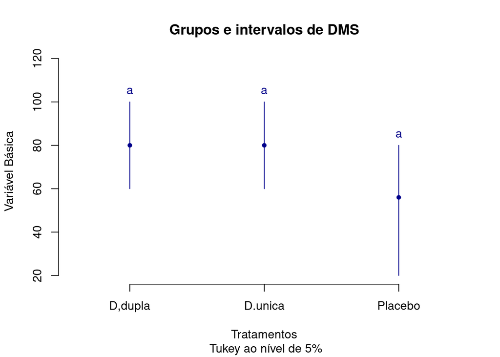

```r
plot(a,xlab="Tratamentos", ylab="Variável Básica", main="Grupos e intervalos de DMS", sub=" Tukey ao nível de 5%")
```